# Stroke Dataset

Read the dataset

```r
df = read.csv("stroke.csv", na.strings = c("N/A"))
head(df)
```

[output not shown]

Which variables has any missing data

```r
colSums(is.na(df))
```

```
##                id            gender               age
##                 0                 0                 0
##      hypertension     heart_disease      ever_married
##                 0                 0                 0
##         work_type    Residence_type avg_glucose_level
##                 0                 0                 0
##               bmi    smoking_status            stroke
##               201                 0                 0
```

Only bmi has some N/A values

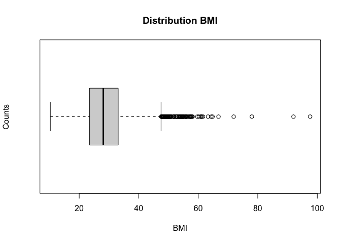

```r
### Missing Values
#Distribution for BMI
boxplot(df$bmi,data=df, main="Distribution BMI",xlab="BMI", ylab="Counts",horizontal= TRUE)
```

```r
#Normality of BMI
shapiro.test(df$bmi)
```

```
##
##  Shapiro-Wilk normality test
##
## data:  df$bmi
## W = 0.95355, p-value < 2.2e-16
```

```r
### Test normality based on Stroke group

data_no_stroke<- subset(df, stroke == 0)
shapiro.test(data_no_stroke$bmi)
```

```
##
##  Shapiro-Wilk normality test
##
## data:  data_no_stroke$bmi
## W = 0.95244, p-value < 2.2e-16
```

```r
data_yes_stroke <- subset(df, stroke == 1)
shapiro.test(data_yes_stroke$bmi)
```

```
##
##  Shapiro-Wilk normality test
##
## data:  data_yes_stroke$bmi
## W = 0.95638, p-value = 5.236e-06
```

## Data changes for missing values in bmi

```r
median_bmi<- median(df$bmi,na.rm = TRUE)
df$bmi <- ifelse(is.na(df$bmi), median_bmi, df$bmi)
colSums(is.na(df))
```

```
##                id            gender               age
##                 0                 0                 0
##      hypertension     heart_disease      ever_married
##                 0                 0                 0
##         work_type    Residence_type avg_glucose_level
##                 0                 0                 0
##               bmi    smoking_status            stroke
##                 0                 0                 0
```

No more missing values after that

## Remove id column from the dataset

```r
df <- subset(df, select = -c(id))
head(df)
```

[output not shown]

# EDA

## Histogram of each variable

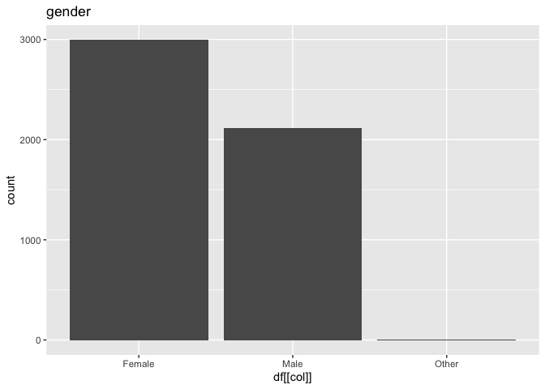

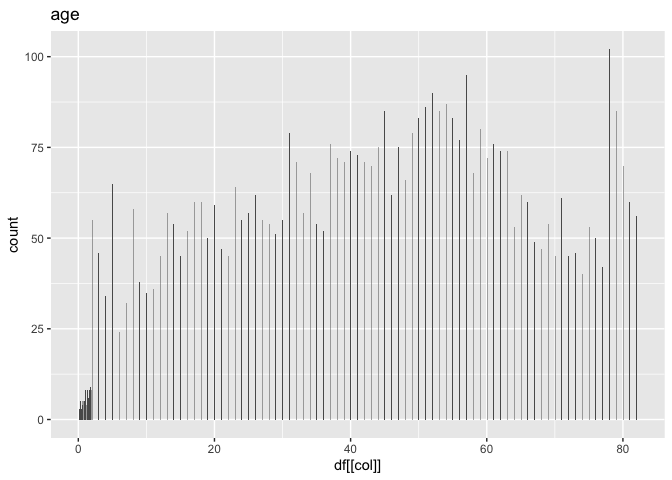

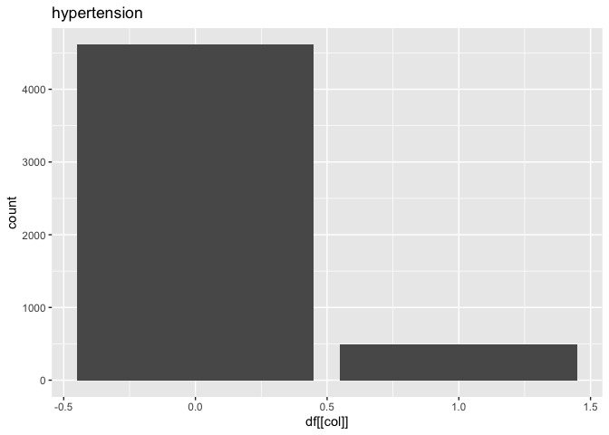

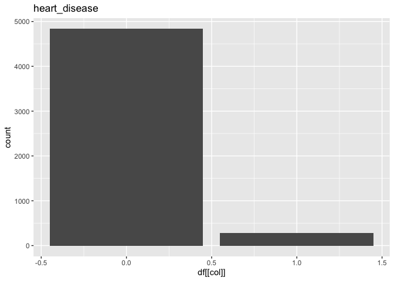

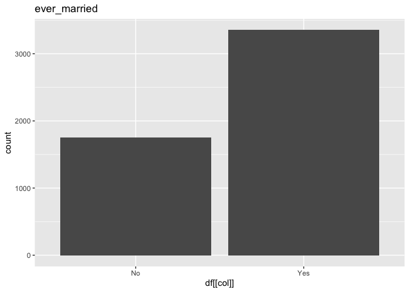

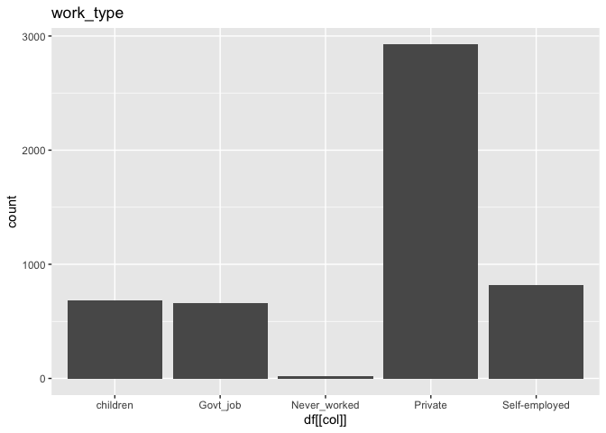

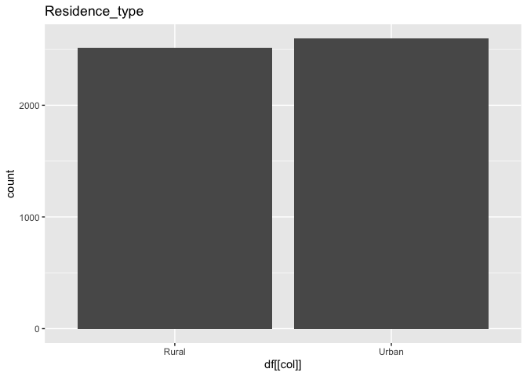

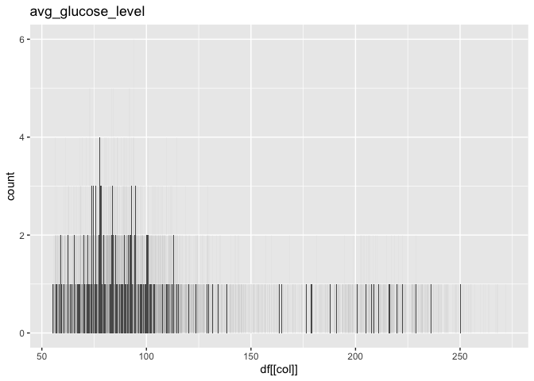

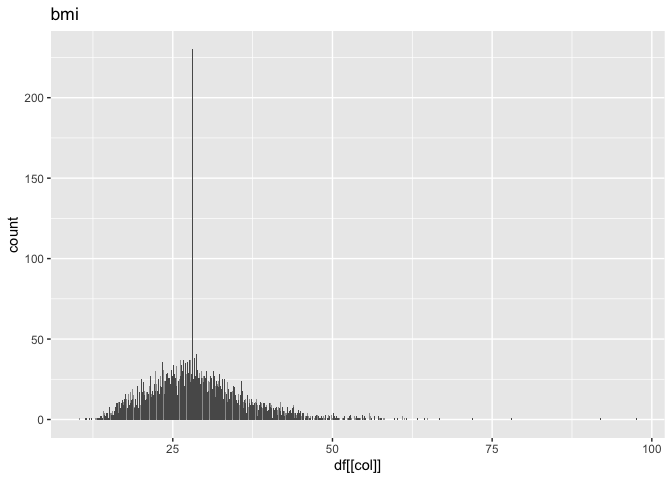

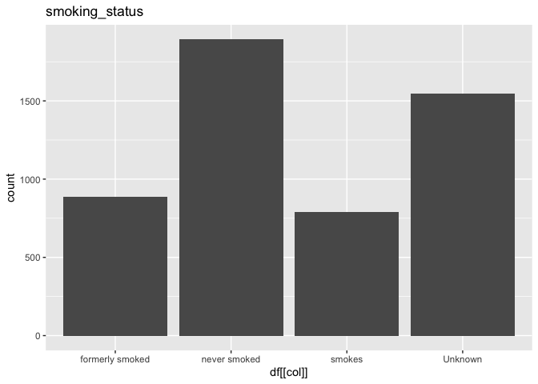

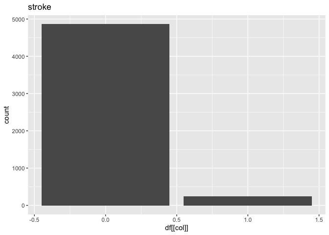

```r
library('ggplot2')

# Create a for loop to generate a histogram for each column
for (col in colnames(df)) {
  p <- ggplot(data = df) +
    geom_bar(mapping = aes(x = df[[col]])) +
    labs(title = col)
  print(p)
}
```

## chi-square test for initial selection for categorical IVs

```r
#DV vs. categorical IVs
stroke_gender_tb <- table(df$stroke, df$gender)
stroke_hypertension_tb <- table(df$stroke, df$hypertension)
stroke_hd_tb <- table(df$stroke, df$heart_disease)
stroke_married_tb <- table(df$stroke, df$ever_married)
stroke_work_tb <- table(df$stroke, df$work_type)
stroke_Residence_tb <- table(df$stroke, df$Residence_type)
stroke_Smoking_tb <- table(df$stroke, df$smoking_status)
```

```r
chisq.test(stroke_gender_tb)
chisq.test(stroke_hypertension_tb)
```

[output not shown]

```
##
##  Pearson's Chi-squared test with Yates' continuity
##  correction
##
## data:  stroke_hypertension_tb
## X-squared = 81.605, df = 1, p-value < 2.2e-16
```

```r
chisq.test(stroke_hd_tb)
```

```
##
##  Pearson's Chi-squared test with Yates' continuity
##  correction
##
## data:  stroke_hd_tb
## X-squared = 90.26, df = 1, p-value < 2.2e-16
```

```r
chisq.test(stroke_married_tb)
```

```
##
##  Pearson's Chi-squared test with Yates' continuity
##  correction
##
## data:  stroke_married_tb
## X-squared = 58.924, df = 1, p-value = 1.639e-14
```

```r
chisq.test(stroke_work_tb)
chisq.test(stroke_Residence_tb)
```

[output not shown]

```
##
##  Pearson's Chi-squared test with Yates' continuity
##  correction
##
## data:  stroke_Residence_tb
## X-squared = 1.0816, df = 1, p-value = 0.2983
```

```r
chisq.test(stroke_Smoking_tb)
```

```
##
##  Pearson's Chi-squared test
##
## data:  stroke_Smoking_tb
## X-squared = 29.147, df = 3, p-value = 2.085e-06
```

## t-test or Mann-Whitney U test for initial selection for continuous IVs

```r
#Normality Assumption
groups <- split(df$bmi,df$stroke)
shapiro_results <- lapply(groups, shapiro.test)
p_values <- sapply(shapiro_results, function(x) x$p.value)
p_values
```

```
##            0            1
## 9.811863e-38 6.427205e-10
```

```r
#Mann-whiteny U test
mwu_result <- wilcox.test(df$bmi, df$stroke)
mwu_result
```

```
##
##  Wilcoxon rank sum test with continuity correction
##
## data:  df$bmi and df$stroke
## W = 26112100, p-value < 2.2e-16
## alternative hypothesis: true location shift is not equal to 0
```

```r
#Normality Assumption
groups <- split(df$age,df$stroke)
shapiro_results <- lapply(groups, shapiro.test)
p_values <- sapply(shapiro_results, function(x) x$p.value)
p_values
```

```
##            0            1
## 1.633259e-30 3.173725e-13
```

```r
#Mann-whiteny U test
mwu_result <- wilcox.test(df$age, df$stroke)
mwu_result
```

```
##
##  Wilcoxon rank sum test with continuity correction
##
## data:  df$age and df$stroke
## W = 26100770, p-value < 2.2e-16
## alternative hypothesis: true location shift is not equal to 0
```

```r
#Normality Assumption
groups <- split(df$avg_glucose_level,df$stroke)
shapiro_results <- lapply(groups, shapiro.test)
p_values <- sapply(shapiro_results, function(x) x$p.value)
p_values
```

```
##            0            1
## 1.147529e-60 1.231952e-13
```

```r
#Mann-whiteny U test
mwu_result <- wilcox.test(df$avg_glucose_level, df$stroke)
mwu_result
```

```
##
##  Wilcoxon rank sum test with continuity correction
##
## data:  df$avg_glucose_level and df$stroke
## W = 26112100, p-value < 2.2e-16
## alternative hypothesis: true location shift is not equal to 0
```

# Multicollinearity

Check for multicollinearity

```r
library(car)
M <- lm(stroke~.,data=df)
vif(M)
```

```
##                       GVIF Df GVIF^(1/(2*Df))
## gender            1.030611  2        1.007566
## age               2.869139  1        1.693853
## hypertension      1.118303  1        1.057499
## heart_disease     1.114817  1        1.055849
## ever_married      1.988336  1        1.410084
## work_type         2.557020  4        1.124519
## Residence_type    1.002762  1        1.001380
## avg_glucose_level 1.108128  1        1.052677
## bmi               1.298832  1        1.139663
## smoking_status    1.439550  3        1.062603
```

# Interaction plots

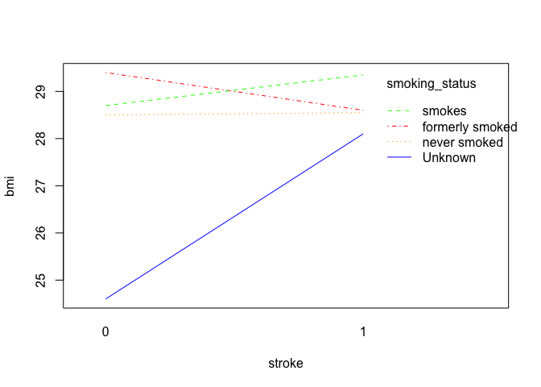

```r
interaction.plot(x.factor = df$stroke,
                 trace.factor = df$smoking_status,
                 response = df$bmi,
                 fun = median,
                 ylab = "bmi",
                 xlab = "stroke",
                 col = c("red", "orange",'green','blue','gray'),
                 trace.label = "smoking_status")
```

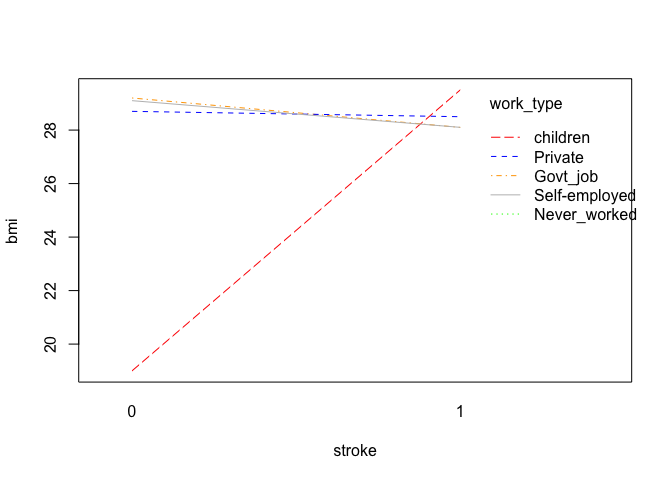

```r
interaction.plot(x.factor = df$stroke,
                 trace.factor = df$work_type,
                 response = df$bmi,
                 fun = median,
                 ylab = "bmi",
                 xlab = "stroke",
                 col = c("red", "orange",'green','blue','gray'),
                 trace.label = "work_type")
```

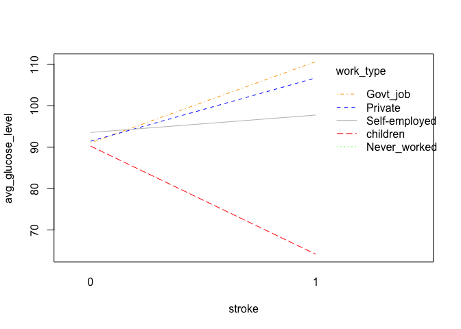

```r
interaction.plot(x.factor = df$stroke,
                 trace.factor = df$work_type,
                 response = df$avg_glucose_level,
                 fun = median,
                 ylab = "avg_glucose_level",
                 xlab = "stroke",
                 col = c("red", "orange",'green','blue','gray'),
                 trace.label = "work_type")
```

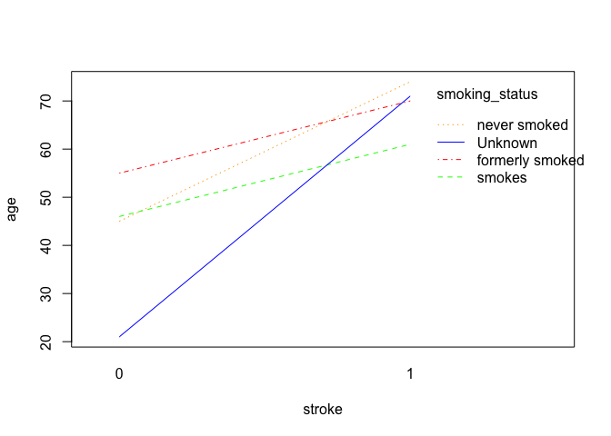

```r
interaction.plot(x.factor = df$stroke,
                 trace.factor = df$smoking_status,
                 response = df$age,
                 fun = median,
                 ylab = "age",
                 xlab = "stroke",
                 col = c("red", "orange",'green','blue','gray'),
                 trace.label = "smoking_status")
```

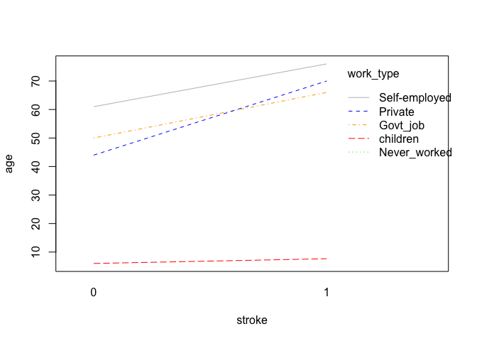

```r
interaction.plot(x.factor = df$stroke,
                 trace.factor = df$work_type,
                 response = df$age,
                 fun = median,
                 ylab = "age",
                 xlab = "stroke",
                 col = c("red", "orange",'green','blue','gray'),
                 trace.label = "work_type")
```

# Train-Test split

```r
library(caret)
library(rlang)
set.seed(123)  # Set a seed for reproducibility
split <- createDataPartition(df$stroke, p = 0.8, list = FALSE)  # Create the train-test split
train <- df[split, ]  # Training data
test <- df[-split, ]  # Testing data
```

```r
dim(train)
```

```
## [1] 4088   11
```

```r
dim(test)
```

```
## [1] 1022   11
```

# Models and variables selection

## Forward Selection

```r
library(MASS)
# Fit the full model
full.model <- lm(stroke~., data = df)
# Stepwise regression model
step.model <- step(full.model, direction = "forward", trace = 0)
summary(step.model)
```

```
##
## Call:
## lm(formula = stroke ~ gender + age + hypertension + heart_disease +
##     ever_married + work_type + Residence_type + avg_glucose_level +
##     bmi + smoking_status, data = df)
##
## Residuals:
##      Min       1Q   Median       3Q      Max
## -0.29449 -0.07888 -0.02394  0.00596  1.02319
##
## Coefficients:
##                              Estimate Std. Error t value Pr(>|t|)
## (Intercept)                -3.217e-02  1.662e-02  -1.935 0.053014
## genderMale                 -1.589e-03  5.942e-03  -0.267 0.789173
## genderOther                -2.804e-02  2.066e-01  -0.136 0.892089
## age                         3.092e-03  2.162e-04  14.300  < 2e-16
## hypertension                3.858e-02  1.029e-02   3.749 0.000180
## heart_disease               5.009e-02  1.348e-02   3.715 0.000205
## ever_marriedYes            -3.447e-02  8.569e-03  -4.023 5.84e-05
## work_typeGovt_job          -6.210e-02  1.522e-02  -4.079 4.59e-05
## work_typeNever_worked      -2.533e-02  4.501e-02  -0.563 0.573570
## work_typePrivate           -4.746e-02  1.280e-02  -3.707 0.000212
## work_typeSelf-employed     -6.696e-02  1.552e-02  -4.316 1.62e-05
## Residence_typeUrban         5.232e-03  5.782e-03   0.905 0.365515
## avg_glucose_level           3.024e-04  6.711e-05   4.506 6.74e-06
## bmi                        -7.178e-04  4.273e-04  -1.680 0.093032
## smoking_statusnever smoked -8.624e-03  8.538e-03  -1.010 0.312551
## smoking_statussmokes       -2.424e-03  1.022e-02  -0.237 0.812504
## smoking_statusUnknown      -1.443e-03  9.655e-03  -0.149 0.881218
##
## (Intercept)                .
## genderMale
## genderOther
## age                        ***
## hypertension               ***
## heart_disease              ***
## ever_marriedYes            ***
## work_typeGovt_job          ***
## work_typeNever_worked
## work_typePrivate           ***
## work_typeSelf-employed     ***
## Residence_typeUrban
## avg_glucose_level          ***
## bmi                        .
## smoking_statusnever smoked
## smoking_statussmokes
## smoking_statusUnknown
## ---
## Signif. codes:  0 '***' 0.001 '**' 0.01 '*' 0.05 '.' 0.1 ' ' 1
##
## Residual standard error: 0.2063 on 5093 degrees of freedom
## Multiple R-squared:  0.08461,    Adjusted R-squared:  0.08173
## F-statistic: 29.42 on 16 and 5093 DF,  p-value: < 2.2e-16
```

From the full model, age, hypertension, heart_disease, ever_married, avg_glucose_level would have an effect. Gender and bmi don’t seem to have an impact.

#### gender

```r
model <- glm(factor(stroke) ~ factor(gender) , data = train, family = "binomial")
summary(model)
```

```
##
## Call:
## glm(formula = factor(stroke) ~ factor(gender), family = "binomial",
##     data = train)
##
## Deviance Residuals:
##     Min       1Q   Median       3Q      Max
## -0.3111  -0.3111  -0.3110  -0.3110   2.4712
##
## Coefficients:
##                       Estimate Std. Error z value Pr(>|z|)
## (Intercept)          -3.004981   0.096374 -31.180   <2e-16 ***
## factor(gender)Male    0.001157   0.149693   0.008    0.994
## factor(gender)Other  -9.561082 324.743710  -0.029    0.977
## ---
## Signif. codes:  0 '***' 0.001 '**' 0.01 '*' 0.05 '.' 0.1 ' ' 1
##
## (Dispersion parameter for binomial family taken to be 1)
##
##     Null deviance: 1555.2  on 4087  degrees of freedom
## Residual deviance: 1555.1  on 4085  degrees of freedom
## AIC: 1561.1
##
## Number of Fisher Scoring iterations: 11
```

gender is NOT significant

#### age

```r
model <- glm(factor(stroke) ~ age , data = train, family = "binomial")
summary(model)
```

```
##
## Call:
## glm(formula = factor(stroke) ~ age, family = "binomial", data = train)
##
## Deviance Residuals:
##     Min       1Q   Median       3Q      Max
## -0.7364  -0.3328  -0.1793  -0.0828   3.7760
##
## Coefficients:
##              Estimate Std. Error z value Pr(>|z|)
## (Intercept) -7.225714   0.379753  -19.03   <2e-16 ***
## age          0.073893   0.005571   13.27   <2e-16 ***
## ---
## Signif. codes:  0 '***' 0.001 '**' 0.01 '*' 0.05 '.' 0.1 ' ' 1
##
## (Dispersion parameter for binomial family taken to be 1)
##
##     Null deviance: 1555.2  on 4087  degrees of freedom
## Residual deviance: 1269.3  on 4086  degrees of freedom
## AIC: 1273.3
##
## Number of Fisher Scoring iterations: 7
```

age is significant

#### hypertension

```r
model <- glm(factor(stroke) ~ factor(hypertension) , data = train, family = "binomial")
summary(model)
```

```
##
## Call:
## glm(formula = factor(stroke) ~ factor(hypertension), family = "binomial",
##     data = train)
##
## Deviance Residuals:
##     Min       1Q   Median       3Q      Max
## -0.5485  -0.2752  -0.2752  -0.2752   2.5662
##
## Coefficients:
##                       Estimate Std. Error z value Pr(>|z|)
## (Intercept)           -3.25472    0.08707 -37.381   <2e-16 ***
## factor(hypertension)1  1.43653    0.16833   8.534   <2e-16 ***
## ---
## Signif. codes:  0 '***' 0.001 '**' 0.01 '*' 0.05 '.' 0.1 ' ' 1
##
## (Dispersion parameter for binomial family taken to be 1)
##
##     Null deviance: 1555.2  on 4087  degrees of freedom
## Residual deviance: 1495.3  on 4086  degrees of freedom
## AIC: 1499.3
##
## Number of Fisher Scoring iterations: 6
```

hypertension is significant

#### age + hypertension

```r
model <- glm(factor(stroke) ~ age + factor(hypertension) , data = train, family = "binomial")
summary(model)
```

```
##
## Call:
## glm(formula = factor(stroke) ~ age + factor(hypertension), family = "binomial",
##     data = train)
##
## Deviance Residuals:
##     Min       1Q   Median       3Q      Max
## -0.8887  -0.3247  -0.1730  -0.0823   3.7640
##
## Coefficients:
##                        Estimate Std. Error z value Pr(>|z|)
## (Intercept)           -7.176716   0.381436 -18.815  < 2e-16 ***
## age                    0.071007   0.005661  12.543  < 2e-16 ***
## factor(hypertension)1  0.628996   0.176857   3.557 0.000376 ***
## ---
## Signif. codes:  0 '***' 0.001 '**' 0.01 '*' 0.05 '.' 0.1 ' ' 1
##
## (Dispersion parameter for binomial family taken to be 1)
##
##     Null deviance: 1555.2  on 4087  degrees of freedom
## Residual deviance: 1257.5  on 4085  degrees of freedom
## AIC: 1263.5
##
## Number of Fisher Scoring iterations: 7
```

Age + Hypertension (AIC: 1263.5) < Age (AIC: 1273.3)  
Age + Hypertension (AIC: 1263.5) < Hypertension (AIC: 1499.3)

```r
pchisq(1269.3-1257.5,4086-4085,lower.tail = FALSE)
```

```
## [1] 0.0005923072
```

```r
pchisq(1495.3-1257.5,4086-4085,lower.tail = FALSE)
```

```
## [1] 1.186896e-53
```

We move on with the full model

#### age + hypertension + heart_disease

```r
model <- glm(factor(stroke) ~ age + factor(hypertension)+factor(heart_disease) , data = train, family = "binomial")
summary(model)
```

```
##
## Call:
## glm(formula = factor(stroke) ~ age + factor(hypertension) + factor(heart_disease),
##     family = "binomial", data = train)
##
## Deviance Residuals:
##     Min       1Q   Median       3Q      Max
## -1.0111  -0.3172  -0.1721  -0.0836   3.7448
##
## Coefficients:
##                         Estimate Std. Error z value Pr(>|z|)
## (Intercept)            -7.101801   0.381984  -18.59  < 2e-16 ***
## age                     0.068960   0.005747   12.00  < 2e-16 ***
## factor(hypertension)1   0.618867   0.177328    3.49 0.000483 ***
## factor(heart_disease)1  0.423614   0.210797    2.01 0.044476 *
## ---
## Signif. codes:  0 '***' 0.001 '**' 0.01 '*' 0.05 '.' 0.1 ' ' 1
##
## (Dispersion parameter for binomial family taken to be 1)
##
##     Null deviance: 1555.2  on 4087  degrees of freedom
## Residual deviance: 1253.7  on 4084  degrees of freedom
## AIC: 1261.7
##
## Number of Fisher Scoring iterations: 7
```

Age + Hypertension + heart_disease (AIC: 1261.7) < Age + Hypertension (AIC: 1263.5)

```r
pchisq(1257.5-1253.7,4085-4084,lower.tail = FALSE)
```

```
## [1] 0.05125258
```

We move on with the reduced model

#### age + hypertension + ever_married

```r
model <- glm(factor(stroke) ~ age + factor(hypertension)+ factor(ever_married) , data = train, family = "binomial")
summary(model)
```

```
##
## Call:
## glm(formula = factor(stroke) ~ age + factor(hypertension) + factor(ever_married),
##     family = "binomial", data = train)
##
## Deviance Residuals:
##     Min       1Q   Median       3Q      Max
## -0.9432  -0.3214  -0.1712  -0.0865   3.7377
##
## Coefficients:
##                          Estimate Std. Error z value Pr(>|z|)
## (Intercept)             -7.078880   0.406328 -17.422  < 2e-16 ***
## age                      0.071593   0.005693  12.576  < 2e-16 ***
## factor(hypertension)1    0.628875   0.176994   3.553 0.000381 ***
## factor(ever_married)Yes -0.154229   0.243230  -0.634 0.526023
## ---
## Signif. codes:  0 '***' 0.001 '**' 0.01 '*' 0.05 '.' 0.1 ' ' 1
##
## (Dispersion parameter for binomial family taken to be 1)
##
##     Null deviance: 1555.2  on 4087  degrees of freedom
## Residual deviance: 1257.1  on 4084  degrees of freedom
## AIC: 1265.1
##
## Number of Fisher Scoring iterations: 7
```

ever_married is NOT significant

#### age + hypertension + work_type

```r
model <- glm(factor(stroke) ~ age + factor(hypertension)+factor(work_type) , data = train, family = "binomial")
summary(model)
```

```
##
## Call:
## glm(formula = factor(stroke) ~ age + factor(hypertension) + factor(work_type),
##     family = "binomial", data = train)
##
## Deviance Residuals:
##     Min       1Q   Median       3Q      Max
## -0.9926  -0.3186  -0.1658  -0.0899   3.4942
##
## Coefficients:
##                                  Estimate Std. Error z value
## (Intercept)                     -6.204698   0.710545  -8.732
## age                              0.077333   0.006277  12.320
## factor(hypertension)1            0.647969   0.177913   3.642
## factor(work_type)Govt_job       -1.487846   0.821552  -1.811
## factor(work_type)Never_worked  -10.636259 333.192372  -0.032
## factor(work_type)Private        -1.236114   0.798678  -1.548
## factor(work_type)Self-employed  -1.710075   0.828648  -2.064
##                                Pr(>|z|)
## (Intercept)                     < 2e-16 ***
## age                             < 2e-16 ***
## factor(hypertension)1           0.00027 ***
## factor(work_type)Govt_job       0.07014 .
## factor(work_type)Never_worked   0.97453
## factor(work_type)Private        0.12169
## factor(work_type)Self-employed  0.03905 *
## ---
## Signif. codes:  0 '***' 0.001 '**' 0.01 '*' 0.05 '.' 0.1 ' ' 1
##
## (Dispersion parameter for binomial family taken to be 1)
##
##     Null deviance: 1555.2  on 4087  degrees of freedom
## Residual deviance: 1248.8  on 4081  degrees of freedom
## AIC: 1262.8
##
## Number of Fisher Scoring iterations: 14
```

Age + Hypertension + work_type (AIC: 1262.8) < Age + Hypertension (AIC: 1263.5)

```r
pchisq(1257.5-1248.8,4085-4081,lower.tail = FALSE)
```

```
## [1] 0.06905145
```

We move on with the reduced model

#### age + hypertension + avg_glucose_level

```r
model <- glm(factor(stroke) ~ age + factor(hypertension) + avg_glucose_level , data = train, family = "binomial")
summary(model)
```

```
##
## Call:
## glm(formula = factor(stroke) ~ age + factor(hypertension) + avg_glucose_level,
##     family = "binomial", data = train)
##
## Deviance Residuals:
##     Min       1Q   Median       3Q      Max
## -1.0293  -0.3207  -0.1696  -0.0800   3.7959
##
## Coefficients:
##                        Estimate Std. Error z value Pr(>|z|)
## (Intercept)           -7.622700   0.407637 -18.700  < 2e-16 ***
## age                    0.069313   0.005754  12.047  < 2e-16 ***
## factor(hypertension)1  0.545035   0.179047   3.044  0.00233 **
## avg_glucose_level      0.004652   0.001290   3.607  0.00031 ***
## ---
## Signif. codes:  0 '***' 0.001 '**' 0.01 '*' 0.05 '.' 0.1 ' ' 1
##
## (Dispersion parameter for binomial family taken to be 1)
##
##     Null deviance: 1555.2  on 4087  degrees of freedom
## Residual deviance: 1245.0  on 4084  degrees of freedom
## AIC: 1253
##
## Number of Fisher Scoring iterations: 7
```

Age + Hypertension + avg_glucose_level (AIC: 1253) < Age + Hypertension (AIC: 1263.5)

```r
pchisq(1257.5-1245.0,4085-4084,lower.tail = FALSE)
```

```
## [1] 0.000406952
```

We move on with the full model

#### age + hypertension + avg_glucose_level + bmi

```r
model <- glm(factor(stroke) ~ age + factor(hypertension) + avg_glucose_level + bmi , data = train, family = "binomial")
summary(model)
```

```
##
## Call:
## glm(formula = factor(stroke) ~ age + factor(hypertension) + avg_glucose_level +
##     bmi, family = "binomial", data = train)
##
## Deviance Residuals:
##     Min       1Q   Median       3Q      Max
## -1.0399  -0.3199  -0.1702  -0.0813   3.7870
##
## Coefficients:
##                        Estimate Std. Error z value Pr(>|z|)
## (Intercept)           -7.414096   0.566711 -13.083  < 2e-16 ***
## age                    0.068824   0.005790  11.887  < 2e-16 ***
## factor(hypertension)1  0.554057   0.180064   3.077 0.002091 **
## avg_glucose_level      0.004803   0.001323   3.631 0.000282 ***
## bmi                   -0.006571   0.012614  -0.521 0.602393
## ---
## Signif. codes:  0 '***' 0.001 '**' 0.01 '*' 0.05 '.' 0.1 ' ' 1
##
## (Dispersion parameter for binomial family taken to be 1)
##
##     Null deviance: 1555.2  on 4087  degrees of freedom
## Residual deviance: 1244.7  on 4083  degrees of freedom
## AIC: 1254.7
##
## Number of Fisher Scoring iterations: 7
```

bmi is NOT significant

#### age + hypertension + avg_glucose_level + smoking_status

```r
model <- glm(factor(stroke) ~ age + factor(hypertension) + avg_glucose_level + factor(smoking_status) , data = train, family = "binomial")
summary(model)
```

```
##
## Call:
## glm(formula = factor(stroke) ~ age + factor(hypertension) + avg_glucose_level +
##     factor(smoking_status), family = "binomial", data = train)
##
## Deviance Residuals:
##     Min       1Q   Median       3Q      Max
## -1.0656  -0.3211  -0.1685  -0.0777   3.8126
##
## Coefficients:
##                                     Estimate Std. Error z value
## (Intercept)                        -7.572961   0.442880 -17.099
## age                                 0.069808   0.005848  11.937
## factor(hypertension)1               0.555004   0.180293   3.078
## avg_glucose_level                   0.004606   0.001291   3.568
## factor(smoking_status)never smoked -0.190077   0.194947  -0.975
## factor(smoking_status)smokes        0.099554   0.242638   0.410
## factor(smoking_status)Unknown      -0.110766   0.237235  -0.467
##                                    Pr(>|z|)
## (Intercept)                         < 2e-16 ***
## age                                 < 2e-16 ***
## factor(hypertension)1               0.00208 **
## avg_glucose_level                   0.00036 ***
## factor(smoking_status)never smoked  0.32955
## factor(smoking_status)smokes        0.68159
## factor(smoking_status)Unknown       0.64057
## ---
## Signif. codes:  0 '***' 0.001 '**' 0.01 '*' 0.05 '.' 0.1 ' ' 1
##
## (Dispersion parameter for binomial family taken to be 1)
##
##     Null deviance: 1555.2  on 4087  degrees of freedom
## Residual deviance: 1243.0  on 4081  degrees of freedom
## AIC: 1257
##
## Number of Fisher Scoring iterations: 7
```

Smoking status is NOT significant

### Comparing models with interaction

#### age + hypertension + avg_glucose_level

```r
model <- glm(factor(stroke) ~ age + factor(hypertension) + avg_glucose_level , data = train, family = "binomial")
summary(model)
```

```
##
## Call:
## glm(formula = factor(stroke) ~ age + factor(hypertension) + avg_glucose_level,
##     family = "binomial", data = train)
##
## Deviance Residuals:
##     Min       1Q   Median       3Q      Max
## -1.0293  -0.3207  -0.1696  -0.0800   3.7959
##
## Coefficients:
##                        Estimate Std. Error z value Pr(>|z|)
## (Intercept)           -7.622700   0.407637 -18.700  < 2e-16 ***
## age                    0.069313   0.005754  12.047  < 2e-16 ***
## factor(hypertension)1  0.545035   0.179047   3.044  0.00233 **
## avg_glucose_level      0.004652   0.001290   3.607  0.00031 ***
## ---
## Signif. codes:  0 '***' 0.001 '**' 0.01 '*' 0.05 '.' 0.1 ' ' 1
##
## (Dispersion parameter for binomial family taken to be 1)
##
##     Null deviance: 1555.2  on 4087  degrees of freedom
## Residual deviance: 1245.0  on 4084  degrees of freedom
## AIC: 1253
##
## Number of Fisher Scoring iterations: 7
```

#### age + hypertension + avg_glucose_level + interaction

All interactions:

- factor(smoking_status):bmi
- factor(work_type):bmi
- factor(work_type):avg_glucose_level
- factor(smoking_status):age
- factor(work_type):age

```r
model_I <- glm(factor(stroke) ~ age + factor(hypertension) + avg_glucose_level + factor(smoking_status):bmi, data = train, family = "binomial")
summary(model_I)
```

```
##
## Call:
## glm(formula = factor(stroke) ~ age + factor(hypertension) + avg_glucose_level +
##     factor(smoking_status):bmi, family = "binomial", data = train)
##
## Deviance Residuals:
##     Min       1Q   Median       3Q      Max
## -1.0749  -0.3196  -0.1680  -0.0791   3.8130
##
## Coefficients:
##                                             Estimate Std. Error
## (Intercept)                               -7.4353296  0.5746836
## age                                        0.0693748  0.0058954
## factor(hypertension)1                      0.5583706  0.1813063
## avg_glucose_level                          0.0047465  0.0013235
## factor(smoking_status)formerly smoked:bmi -0.0040521  0.0131402
## factor(smoking_status)never smoked:bmi    -0.0102162  0.0131398
## factor(smoking_status)smokes:bmi          -0.0007618  0.0138166
## factor(smoking_status)Unknown:bmi         -0.0092245  0.0138948
##                                           z value Pr(>|z|)
## (Intercept)                               -12.938  < 2e-16 ***
## age                                        11.768  < 2e-16 ***
## factor(hypertension)1                       3.080 0.002072 **
## avg_glucose_level                           3.586 0.000335 ***
## factor(smoking_status)formerly smoked:bmi  -0.308 0.757794
## factor(smoking_status)never smoked:bmi     -0.778 0.436861
## factor(smoking_status)smokes:bmi           -0.055 0.956031
## factor(smoking_status)Unknown:bmi          -0.664 0.506767
## ---
## Signif. codes:  0 '***' 0.001 '**' 0.01 '*' 0.05 '.' 0.1 ' ' 1
##
## (Dispersion parameter for binomial family taken to be 1)
##
##     Null deviance: 1555.2  on 4087  degrees of freedom
## Residual deviance: 1242.6  on 4080  degrees of freedom
## AIC: 1258.6
##
## Number of Fisher Scoring iterations: 7
```

The interaction is NOT significant

Age + Hypertension + avg_glucose_level (AIC: 1253) < age + hypertension + avg_glucose_level + interaction (AIC: 1258.6)

```r
pchisq(1245-1242.6,4084-4080,lower.tail = FALSE)
```

```
## [1] 0.6626273
```

Reduced model is better: age + hypertension + avg_glucose_level

### Classification Report

```r
table(df$stroke)
```

```
##
##    0    1
## 4861  249
```

```r
#probability of stroke = class 1
249 / (4861 + 249)
```

```
## [1] 0.04872798
```

```r
model <- glm(stroke ~ age + hypertension + avg_glucose_level, data = train, family = binomial)
pred <- predict(model, newdata = test, type = "response")
pred_class <- ifelse(pred > 0.04872798, 1, 0)
classification_table <- table(actual = test$stroke, predicted = pred_class)
classification_table
```

```
##       predicted
## actual   0   1
##      0 731 235
##      1  17  39
```

```r
TP <- classification_table[2,2]
FP <- classification_table[1,2]
TN <- classification_table[1,1]
FN <- classification_table[2,1]

sensitivity <- TP / (TP + FN)
specificity <- TN / (TN + FP)
accuracy <- (TP + TN)/ (TP + FN + TN + FP)

c(sensitivity,specificity,accuracy)
```

```
## [1] 0.6964286 0.7567288 0.7534247
```

### ROC Curve

```r
#Without interaction

library(pROC)
```

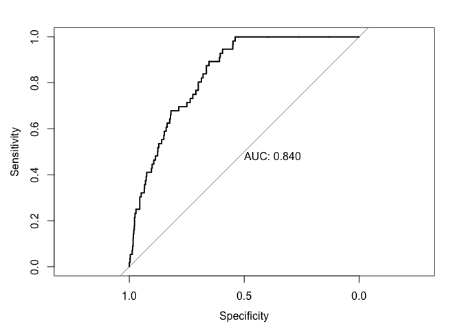

```r
test_roc <- roc(test$stroke ~ pred, plot = TRUE, print.auc = TRUE)
```

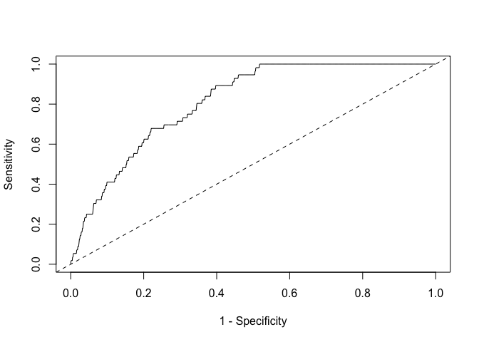

```r
spec_rev <- rev(1 - test_roc$specificities)

# Plot the ROC curve with 1 - specificity on the x-axis
plot(1 - spec_rev, test_roc$sensitivities, type = "l", xlab = "1 - Specificity", ylab = "Sensitivity")
abline(a = 0, b = 1, lty = 2)
```

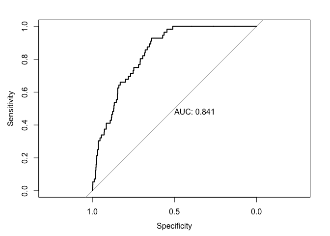

```r
#With interaction
pred <- predict(model_I, newdata = test, type = "response")
test_roc <- roc(test$stroke ~ pred, plot = TRUE, print.auc = TRUE)
```

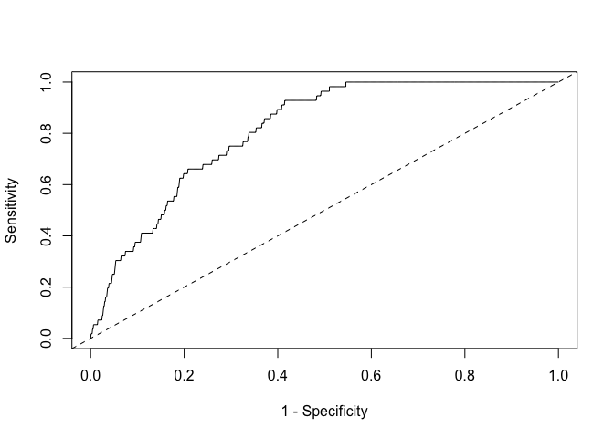

```r
spec_rev <- rev(1 - test_roc$specificities)

# Plot the ROC curve with 1 - specificity on the x-axis
plot(1 - spec_rev, test_roc$sensitivities, type = "l", xlab = "1 - Specificity", ylab = "Sensitivity")
abline(a = 0, b = 1, lty = 2)
```